# BASIL Reference Standard (Clinical Assessor)

Author

Doug Tommet and Rich Jones for Anna MacKay-Brandt, Tamara G Fong, and the BASIL-II team

Published

July 10, 2025

```
Converged within tolerance
```

## Aims of manuscript:

1. Describe clinical assessor inter-rater reliability for *delirium severity* ratings:
   1. Overall agreement among clinical assessors
      1. Before consensus meeting *(for generalizability - this is the result that is [more or less] generalizable to other research studies using a single clinical rater for delirium)*
      2. After consensus meeting *(this is the result that describes the reliability of the clinical assessor rating of delirium in the BASIL-II study)*.
   2. Variability in agreement as a function delirium severity (Bland-Altman plots)
2. Explore if there are *delirium features* that are associated with delirium severity inter-rater agreement (e.g., features present include Inattention, Disorganized Thinking, Altered Level of Consciousness, Disorientation, Memory Impairment, Perceptual Disturbances, Psychomotor Agitation, Psychomotor Retardation, Altered Sleep-Wake, Inappropriate Behavior, Delusions).
3. Explore if there are *patient characteristics* that may influence delirium severity inter-rater agreement (e.g., pre-acute cognitive status (NC, MCI, Dementia), three distinct study sites: (1) acute medical inpatients; (2) scheduled surgical inpatients, and (3) long-term and post-acute care residents; informant (family member/friend, nurse, CNA), pre-acute depression)

Note: Aims of manuscript copied from Statistical Analysis Plan ([GDoc](https://docs.google.com/document/d/1GPIzetmxAJxbsQnpXG5_sj9buN0inlTDNljtyg4V1vE/edit?usp=sharing))

## This analysis report (28 Apr 2025)

- The goal of this analysis report is to provide a description of the data for analysis. Variables needed are described in the [SAP](https://docs.google.com/document/d/1GPIzetmxAJxbsQnpXG5_sj9buN0inlTDNljtyg4V1vE/edit?usp=sharing).

Some variables are not yet defined in precise terms, and may warrant discussion:

- **Aim 1 requires**
  - CAM-S scores, before and after consensus, in total BASIL-II sample
  - Indicator for membership in clinical assessor reliability study (n = 46)
  - Separate ratings for pre vs post consensus meeting
  - Characteristics for description of the sample:
    - Age
    - Sex
    - Εducation
    - English as a first language
    - Vision impairment
    - Hearing impairment
    - Depressive symptoms (PHQ)
    - Cognitive performance (MoCA)
    - Dementia (reference standard) *do we mean gold standard? \rnj*
    - AD-8
    - ADL dependence
    - IADL difficulties
    - Delirium (reference standard) *do we mean gold standard? \rnj*
  - Characteristics to model selection into reliability study (*TBD* right now planning on using the factors listed above, but really should be 4-5 predictors)
    - **ACTION**: Need to generate VDSs for ADL and IADL characteristics
    - **ACTION**: Replace REDCap PHQ, MoCA, and AD-8 summary measures with VDS versions
- **Aim 2 additionally requires**
  - Individual delirium features (inattention, disorganized thinking, altered level of consciousness, disorientation, memory impairment, perceptual disturbances, psychomotor agitation, psychomotor retardation, altered sleep-wake, inappropriate behavior, delusions)
    - **ACTION**: Need to modify vds for CAM-S to generate and save individual indicators for the CAM features (0/1)
- **Aim 3 additionally requires**
  - “pre-acute” cognitive status
  - patient group (really, study site) three distinct study sites: (1) acute medical inpatients; (2) scheduled surgical inpatients, and (3) long-term and post-acute care residents
  - informant (family member/friend, nurse, CNA),
  - pre-acute depression

*Note:* **None of the aim 3 variables are pulled**: these need to be defined more precisely (i.e., with respect to REDCap data collected). All I can see in that list that can be consistently measured across site is, `site` itself. \rnj

## This analysis report (02 May 2025)

- Updated handling of delirium severity ratings (0-9), see below
- **ACTION**: Need to generate VDSs for ADL and IADL characteristics
- **ACTION**: Replace REDCap PHQ, MoCA, and AD-8 summary measures with VDS versions
- **ACTION** Aim 2 additionally requires individual CAM-S delirium features (inattention, disorganized thinking, altered level of consciousness, disorientation, memory impairment, perceptual disturbances, psychomotor agitation, psychomotor retardation, altered sleep-wake, inappropriate behavior, delusions), need to modify vds for CAM-S to generate and save individual indicators for the CAM features (0/1)

## This analysis report (30 May 2025)

- This report includes heatmaps and Bland-Altman figures for rater agreement.
- **ACTION**: Need to create IPTW weights for selection into the sample
- **ACTION**: Need to generate VDSs for ADL and IADL characteristics
- **ACTION**: Replace REDCap PHQ, MoCA, and AD-8 summary measures with VDS versions
- **ACTION** Aim 2 additionally requires individual CAM-S delirium features (inattention, disorganized thinking, altered level of consciousness, disorientation, memory impairment, perceptual disturbances, psychomotor agitation, psychomotor retardation, altered sleep-wake, inappropriate behavior, delusions), need to modify vds for CAM-S to generate and save individual indicators for the CAM features (0/1)

## This analysis report (06 June 2025)

- This report includes updated heatmaps and Bland-Altman figures for rater agreement. The figures were done in a grayscale color scheme. It also includes scatter plot figures for rater agreement.
- **ACTION**: Need to create IPTW weights for selection into the sample
- **ACTION**: Need to generate VDSs for ADL and IADL characteristics
- **ACTION**: Replace REDCap PHQ, MoCA, and AD-8 summary measures with VDS versions
- **ACTION** Aim 2 additionally requires individual CAM-S delirium features (inattention, disorganized thinking, altered level of consciousness, disorientation, memory impairment, perceptual disturbances, psychomotor agitation, psychomotor retardation, altered sleep-wake, inappropriate behavior, delusions), need to modify vds for CAM-S to generate and save individual indicators for the CAM features (0/1)

## Data handling notes

**RS ratings and their updates given consensus**

We assume that when a rating appears with an arrow, e.g, “9 -> 6”, this means that the rating was updated from 9 to 6 after the consensus process.

**Dementia severity ratings**

RS adjudication dementia severity categories were provided as 5 text labels. We have ordered these into 5 numeric categories with the following ordering (see `new_order`):

| Freq. | Numeric | New Order | Labels provided |
| --- | --- | --- | --- |
| 79 | 3 | 0 | no dementia (equivalent to no neurocognitive disorder) |
| 81 | 5 | 1 | very mild (equivalent to minor neurocognitive disorder) |
| 89 | 1 | 2 | mild |
| 63 | 2 | 3 | moderate |
| 8 | 4 | 4 | severe |

Note: `Freq`-uency is the number of 320 adjudcations among 46 participants. `Numeric` is the oder assigned to the provided text labels in `Labels provided`, and are sorted alphabetically. `New Order` is the order we have assigned to the numeric labels, and is used in the analysis.

**Codebook listing**

```
------------------------------------------------------------------------------------
studyid                                                                  (unlabeled)
------------------------------------------------------------------------------------

                  Type: String (str7)

         Unique values: 46                        Missing "": 0/320

              Examples: "DB43364"
                        "TN60081"
                        "TN60363"
                        "UF50103"

------------------------------------------------------------------------------------
rsadjname                                                                Adjudicator
------------------------------------------------------------------------------------

                  Type: String (str20)

         Unique values: 7                         Missing "": 0/320

            Tabulation: Freq.  Value
                           46  "Anna MacKay-Brandt"
                           46  "Benjamin Chapin"
                           46  "Cate Price"
                           46  "Juliana Burt"
                           46  "Kerry Palihnich"
                           44  "Rebecca Avila-Rieger"
                           46  "Wingyun Mak"

               Warning: Variable has embedded blanks.

------------------------------------------------------------------------------------
rsadjdate                                                                       Date
------------------------------------------------------------------------------------

                  Type: Numeric daily date (int)

                 Range: [23408,23621]                 Units: 1
       Or equivalently: [02feb2024,02sep2024]         Units: days
```

[output cut: 50 more lines]

```

------------------------------------------------------------------------------------
deliriumseverity_2n                                    Delirium Severity (consensus)
------------------------------------------------------------------------------------

                  Type: Numeric (long)
                 Label: deliriumseverity_2n

                 Range: [1,13]                        Units: 1
         Unique values: 13                        Missing .: 0/320

              Examples: 1     0
                        2     1
                        5     4
                        9     6
```

**Question(s)** Is the 1-13 scale really correct? These are CAM-S scores? CAM-S scores do potentially range from 0-19, with 19 being the most severe.

```
------------------------------------------------------------------------------------
ncdpresence_1n                                                NCD Presence (initial)
------------------------------------------------------------------------------------

                  Type: Numeric (long)
                 Label: ncd_status

                 Range: [1,3]                         Units: 1
         Unique values: 3                         Missing .: 0/320

            Tabulation: Freq.   Numeric  Label
                           80         1  no NCD
                           84         2  Minor NCD
                          156         3  Major NCD

------------------------------------------------------------------------------------
ncdpresence_2n                                              NCD Presence (consensus)
------------------------------------------------------------------------------------

                  Type: Numeric (long)
                 Label: ncd_status

                 Range: [1,3]                         Units: 1
         Unique values: 3                         Missing .: 0/320

            Tabulation: Freq.   Numeric  Label
                           76         1  no NCD
                           78         2  Minor NCD
                          166         3  Major NCD

------------------------------------------------------------------------------------
dementiaseverity_1n                                      Dementia Severity (initial)
------------------------------------------------------------------------------------

                  Type: Numeric (long)
                 Label: cogn_status

                 Range: [0,4]                         Units: 1
         Unique values: 5                         Missing .: 0/320

```

[output cut: 8 more lines]

```
dementiaseverity_2n                                    Dementia Severity (consensus)
------------------------------------------------------------------------------------

                  Type: Numeric (long)
                 Label: cogn_status

                 Range: [0,4]                         Units: 1
         Unique values: 5                         Missing .: 0/320

            Tabulation: Freq.   Numeric  Label
                           76         0  no dementia
                           77         1  very mild (Minor NCD)
                          100         2  mild
                           57         3  moderate
                           10         4  severe
```

```
    Variable        |        Obs       Mean    sd       Min        Max
--------------------+---------------------------------------------------------
deliriumpresence_1n |        320       1.44    .50       1          2
deliriumpresence_2n |        320       1.45    .50       1          2
--------------------+---------------------------------------------------------
dementiaseverity_1n |        320       4.09    3.13      1         11
dementiaseverity_2n |        320       4.44    3.59      1         13
--------------------+---------------------------------------------------------
ncdpresence_1n      |        320       2.25    .83       1          3
ncdpresence_2n      |        320       2.28    .82       1          3
--------------------+---------------------------------------------------------
dementiaseverity_1n |        320       1.50    1.14      0          4
dementiaseverity_2n |        320       1.53    1.13      0          4
```

# Read BASIL RS data

The BASIL RS data comes from the spreadsheet `SourceData/FINAL RS IRR Ratings.xlsx`.

## RS ratings

The initial and consesus ratings were stored in a column with values such as “3 -> 5” indicating the initial rating as a 3 and then after consensus it was updated to a 5. This column was split into two columns for initial rating and consensus rating.

## Dementia severity ratings

The dementia severity rating were one of five unordered text labels. We put them into the following order.

| Label | Order |
| --- | --- |
| No dementia (equivalent to no neurocognitive disorder) | 0 |
| Very mild (equivalent to minor neurocognitive disorder) | 1 |
| Mild | 2 |
| Moderate | 3 |
| Severe | 4 |

## NCD presence

The NCD presence ratings were one of three unordered text labels. We put them into the following order.

[output not shown]

## N46 data file

A file of the studyid’s of the 46 participants that were part of this rating process was created.

# Read BASIL data

The main BASIL data came from `BASILIIMainStudy_Derived.dta`.

# Data munging

The variables of interest (vdsite, vdage, vdfemale, vdeduc, vdhisp, vdesl, vdvisionimp, vdhearingimp, vdcharlson, vdmajneurogs, vdminneurogs, vddeliriumgs, vdcamsrs, phq_9_score, moca_score, ad8_total_score) were kept from the main BASIL data. Missing values were filled in from data collected at other Redcap records. The data was then filtered to one record per participant (n=488).

# IPTW

## Comparison of clinical assessor sample

|  | In the clinical adjudication sample FALSE | In the clinical adjudication sample TRUE | Total |  |
| --- | --- | --- | --- | --- |
| Delirium severity (GS) |  |  |  |  |
| 0 | 217 (49%) | 21 (46%) | 238 (49%) |  |
| 1 | 66 (15%) | 4 (8.7%) | 70 (14%) |  |
| 2 | 22 (5.0%) | 0 (0%) | 22 (4.5%) |  |
| 3 | 28 (6.3%) | 2 (4.3%) | 30 (6.1%) |  |
| 4 | 47 (11%) | 7 (15%) | 54 (11%) |  |
| 5 | 37 (8.4%) | 4 (8.7%) | 41 (8.4%) |  |
| 6 | 17 (3.8%) | 5 (11%) | 22 (4.5%) |  |
| 7 | 4 (0.9%) | 2 (4.3%) | 6 (1.2%) |  |
| 8 | 4 (0.9%) | 1 (2.2%) | 5 (1.0%) |  |
| Total | 442 (100%) | 46 (100%) | 488 (100%) |  |

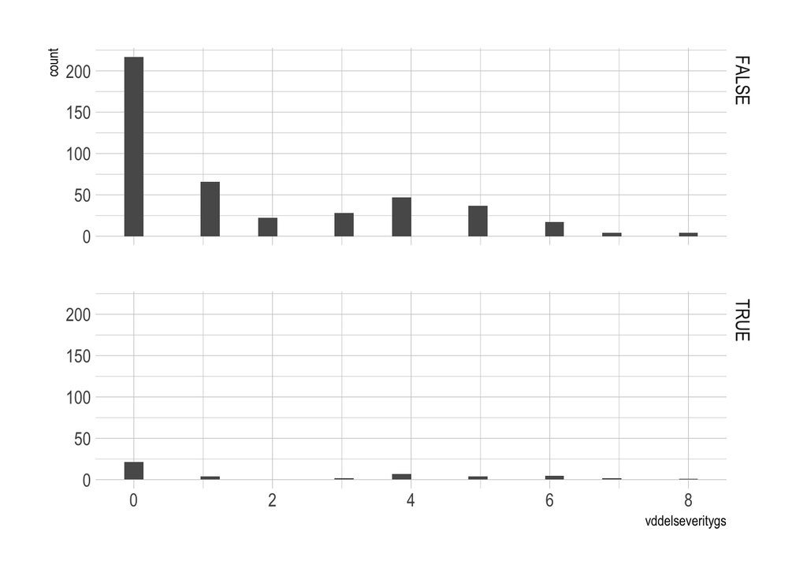

## Calculating the weights

We considered two methods to calculate the weights. The first was using logistic regression. The second was called entropy balancing. Both models controlled for delirium severity (GS) and site. We are going with the entropy balancing weights.

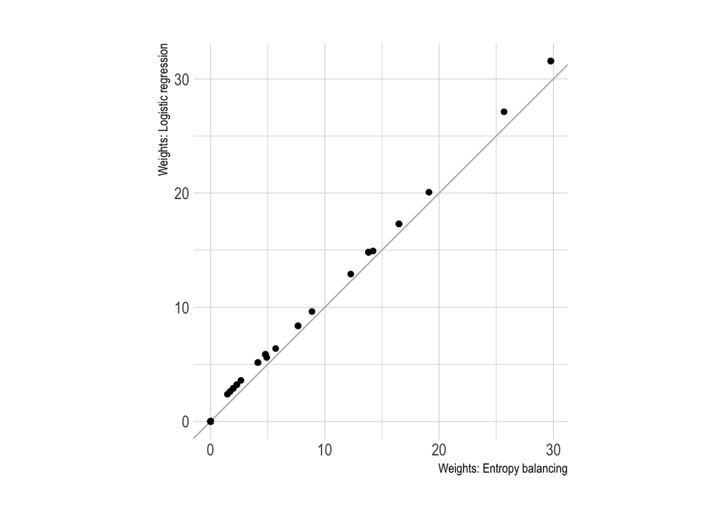

## Comparison of weighted and unweighted sample

Mean of delirium severity, stratified by clinical assessor sample.

| **Characteristic** | **Overall** N = 488<sup>1</sup> | **TRUE** N = 46<sup>1</sup> | **FALSE** N = 442<sup>1</sup> |
| --- | --- | --- | --- |
| Delirium severity (GS) | 1.72 (2.16) | 2.39 (2.64) | 1.65 (2.10) |

<sup>1</sup> Mean (SD)

Weighted mean of delirium severity in the clinical assessor sample.

| **Characteristic** | **N = 442**<sup>1</sup> |
| --- | --- |
| Delirium severity (GS) | 1.65 (2.20) |

<sup>1</sup> Mean (SD)

# Create all rater pairs

The BASIL RS data was transformed so that all of the unique rater pairs are created. There are seven raters so that results in 21 (6+5+4+3+2+1) unique pairs per participant. With 46 participants, if there were no missing data, this would be 21 * 46 = 966 pairs. One rater missed two participants so there are only 954 pairs.

In the resulting data file the raters were assigned the following ids.

| Rater | ID |
| --- | --- |
| Anna MacKay-Brandt | 1 |
| Benjamin Chapin | 2 |
| Cate Price | 3 |
| Juliana Burt | 4 |
| Kerry Palihnich | 5 |
| Rebecca Avila-Rieger | 6 |
| Wingyun Mak | 7 |

# Table 1

Table 1: Descriptive statistics of the RS sample

| **Characteristic** | **Overall** N = 46<sup>1</sup> | **BIDMC** N = 10<sup>1</sup> | **UF** N = 14<sup>1</sup> | **TNJH** N = 22<sup>1</sup> |
| --- | --- | --- | --- | --- |
| Age | 80.0 (6.2) | 80.1 (7.2) | 77.4 (3.9) | 81.5 (6.7) |
| Female |  |  |  |  |
| Male | 19 (41%) | 4 (40%) | 7 (50%) | 8 (36%) |
| Female | 27 (59%) | 6 (60%) | 7 (50%) | 14 (64%) |
| Non-white | 15 (33%) | 2 (20%) | 1 (7.1%) | 12 (55%) |
| Hispanic ethnicity |  |  |  |  |
| Not Hispanic | 46 (100%) | 10 (100%) | 14 (100%) | 22 (100%) |
| Hispanic | 0 (0%) | 0 (0%) | 0 (0%) | 0 (0%) |
| English is second language | 1 (2.2%) | 0 (0%) | 0 (0%) | 1 (4.5%) |
| Education | 14.3 (3.2) | 14.5 (2.7) | 14.7 (2.6) | 14.0 (3.7) |
| Unknown | 1 | 0 | 0 | 1 |
| Lives alone | 9 (20%) | 5 (50%) | 4 (29%) | 0 (0%) |
| Married | 15 (33%) | 2 (20%) | 10 (71%) | 3 (14%) |
| Lives in NH | 22 (48%) | 0 (0%) | 0 (0%) | 22 (100%) |
| Vision impairment | 16 (39%) | 2 (20%) | 3 (21%) | 11 (65%) |
| Unknown | 5 | 0 | 0 | 5 |
| Hearing impairment | 14 (30%) | 2 (20%) | 4 (29%) | 8 (36%) |
| Charlson Comorbidity Index |  |  |  |  |
| 0 | 11 (24%) | 2 (20%) | 4 (31%) | 5 (23%) |
| 1 | 3 (6.7%) | 1 (10%) | 2 (15%) | 0 (0%) |
| 2+ | 31 (69%) | 7 (70%) | 7 (54%) | 17 (77%) |
| Unknown | 1 | 0 | 1 | 0 |
| Major neurocognitive disorder (GS) | 27 (59%) | 3 (30%) | 3 (21%) | 21 (95%) |
| Minor neurocognitive disorder (GS) | 9 (20%) | 5 (50%) | 3 (21%) | 1 (4.5%) |
| Delirium diagnosis (GS) | 21 (46%) | 6 (60%) | 6 (43%) | 9 (41%) |
| Delirium severity (GS) |  |  |  |  |
| 0 | 21 (46%) | 3 (30%) | 8 (57%) | 10 (45%) |
| 1 | 4 (8.7%) | 1 (10%) | 0 (0%) | 3 (14%) |
| 2 | 0 (0%) | 0 (0%) | 0 (0%) | 0 (0%) |
| 3 | 2 (4.3%) | 1 (10%) | 1 (7.1%) | 0 (0%) |
| 4 | 7 (15%) | 3 (30%) | 3 (21%) | 1 (4.5%) |
| 5 | 4 (8.7%) | 1 (10%) | 0 (0%) | 3 (14%) |
| 6 | 5 (11%) | 1 (10%) | 1 (7.1%) | 3 (14%) |
| 7 | 2 (4.3%) | 0 (0%) | 1 (7.1%) | 1 (4.5%) |
| 8 | 1 (2.2%) | 0 (0%) | 0 (0%) | 1 (4.5%) |
| 9 | 0 (0%) | 0 (0%) | 0 (0%) | 0 (0%) |
| 10 | 0 (0%) | 0 (0%) | 0 (0%) | 0 (0%) |
| Dementia severity (GS) |  |  |  |  |
| No dementia | 10 (22%) | 2 (20%) | 8 (57%) | 0 (0%) |
| Very Mild | 9 (20%) | 5 (50%) | 3 (21%) | 1 (4.5%) |
| Mild | 17 (37%) | 3 (30%) | 2 (14%) | 12 (55%) |
| Moderate | 10 (22%) | 0 (0%) | 1 (7.1%) | 9 (41%) |
| Severe | 0 (0%) | 0 (0%) | 0 (0%) | 0 (0%) |
| vdcamsrs | 3.22 (2.60) | 4.20 (2.82) | 0.71 (0.73) | 4.36 (2.17) |
| PHQ-9 score | 5.5 (3.8) | 5.6 (2.7) | 4.9 (2.7) | 5.9 (4.7) |
| MOCA score | 17 (6) | 20 (5) | 18 (6) | 14 (6) |
| AD8 total score |  |  |  |  |
| 0 | 25 (54%) | 4 (40%) | 8 (57%) | 13 (59%) |
| 1 | 4 (8.7%) | 1 (10%) | 2 (14%) | 1 (4.5%) |
| 2 | 8 (17%) | 2 (20%) | 2 (14%) | 4 (18%) |
| 3 | 2 (4.3%) | 0 (0%) | 1 (7.1%) | 1 (4.5%) |
| 4 | 3 (6.5%) | 1 (10%) | 0 (0%) | 2 (9.1%) |
| 5 | 1 (2.2%) | 0 (0%) | 0 (0%) | 1 (4.5%) |
| 7 | 2 (4.3%) | 2 (20%) | 0 (0%) | 0 (0%) |
| 8 | 1 (2.2%) | 0 (0%) | 1 (7.1%) | 0 (0%) |

<sup>1</sup> Mean (SD); n (%)

Table 2: Descriptive statistics of the RS sample (weighted)

| **Characteristic** | **Overall** N = 442<sup>1</sup> | **BIDMC** N = 210<sup>1</sup> | **UF** N = 153<sup>1</sup> | **TNJH** N = 79<sup>1</sup> |
| --- | --- | --- | --- | --- |
| Age | 79 (6) | 80 (7) | 77 (3) | 81 (7) |
| Female | 254 (58%) | 135 (64%) | 71 (46%) | 49 (62%) |
| Non-white | 93 (21%) | 46 (22%) | 6 (3.7%) | 41 (52%) |
| Hispanic ethnicity |  |  |  |  |
| 0 | 442 (100%) | 210 (100%) | 153 (100%) | 79 (100%) |
| English is second language | 5 (1.1%) | 0 (0%) | 0 (0%) | 5 (6.1%) |
| Education | 14.61 (2.92) | 14.70 (2.84) | 15.04 (2.75) | 13.48 (3.63) |
| Unknown | 5 | 0 | 0 | 5 |
| Lives alone | 156 (35%) | 118 (56%) | 38 (25%) | 0 (0%) |
| Married | 172 (39%) | 49 (23%) | 115 (75%) | 8 (10%) |
| Lives in NH | 79 (18%) | 0 (0%) | 0 (0%) | 79 (100%) |
| Vision impairment | 89 (21%) | 29 (14%) | 27 (18%) | 33 (54%) |
| Unknown | 17 | 0 | 0 | 17 |
| Hearing impairment | 124 (28%) | 45 (21%) | 49 (32%) | 30 (38%) |
| Charlson Comorbidity Index |  |  |  |  |
| 0 | 106 (24%) | 46 (22%) | 44 (30%) | 16 (20%) |
| 1 | 51 (12%) | 30 (14%) | 21 (15%) | 0 (0%) |
| 2+ | 279 (64%) | 134 (64%) | 82 (55%) | 63 (80%) |
| Unknown | 6 | 0 | 6 | 0 |
| Major neurocognitive disorder (GS) | 168 (38%) | 59 (28%) | 35 (23%) | 74 (94%) |
| Minor neurocognitive disorder (GS) | 115 (26%) | 92 (44%) | 18 (12%) | 5 (6.1%) |
| Delirium diagnosis (GS) | 156 (35%) | 95 (45%) | 42 (28%) | 19 (24%) |
| Delirium severity (GS) |  |  |  |  |
| 0 | 248 (56%) | 89 (43%) | 111 (72%) | 48 (61%) |
| 1 | 38 (8.6%) | 26 (12%) | 0 (0%) | 12 (16%) |
| 3 | 28 (6.3%) | 19 (9.1%) | 9 (5.8%) | 0 (0%) |
| 4 | 75 (17%) | 49 (24%) | 23 (15%) | 3 (3.4%) |
| 5 | 21 (4.8%) | 14 (6.8%) | 0 (0%) | 7 (8.7%) |
| 6 | 24 (5.4%) | 12 (5.8%) | 6 (3.7%) | 6 (7.5%) |
| 7 | 7 (1.5%) | 0 (0%) | 5 (3.2%) | 2 (2.2%) |
| 8 | 1 (0.3%) | 0 (0%) | 0 (0%) | 1 (1.9%) |
| Dementia severity (GS) |  |  |  |  |
| 1 | 159 (36%) | 60 (28%) | 99 (65%) | 0 (0%) |
| 2 | 115 (26%) | 92 (44%) | 18 (12%) | 5 (6.1%) |
| 3 | 124 (28%) | 59 (28%) | 21 (14%) | 44 (55%) |
| 4 | 44 (10%) | 0 (0%) | 14 (9.0%) | 30 (38%) |
| vdcamsrs | 2.66 (2.56) | 3.45 (2.77) | 0.71 (0.78) | 4.31 (2.18) |
| PHQ-9 score | 5.22 (3.00) | 5.84 (2.60) | 4.33 (2.68) | 5.30 (4.28) |
| MOCA score | 19 (6) | 21 (5) | 19 (5) | 14 (6) |
| AD8 total score |  |  |  |  |
| 0 | 213 (48%) | 80 (38%) | 82 (54%) | 51 (64%) |
| 1 | 49 (11%) | 26 (12%) | 21 (14%) | 2 (2.2%) |
| 2 | 85 (19%) | 42 (20%) | 28 (18%) | 16 (20%) |
| 3 | 10 (2.2%) | 0 (0%) | 8 (5.0%) | 2 (2.9%) |
| 4 | 34 (7.7%) | 30 (14%) | 0 (0%) | 4 (5.4%) |
| 5 | 4 (0.9%) | 0 (0%) | 0 (0%) | 4 (5.2%) |
| 7 | 33 (7.5%) | 33 (16%) | 0 (0%) | 0 (0%) |
| 8 | 14 (3.1%) | 0 (0%) | 14 (9.0%) | 0 (0%) |

<sup>1</sup> Mean (SD); n (%)

# Rater agreement

## Delirium severity

Crosstab of paired initial ratings of delirium severity

|  | Delirium Severity (Rater A) 0 | Delirium Severity (Rater A) 1 | Delirium Severity (Rater A) 2 | Delirium Severity (Rater A) 3 | Delirium Severity (Rater A) 4 | Delirium Severity (Rater A) 5 | Delirium Severity (Rater A) 6 | Delirium Severity (Rater A) 7 | Delirium Severity (Rater A) 8 | Delirium Severity (Rater A) 9 | Total |  |
| --- | --- | --- | --- | --- | --- | --- | --- | --- | --- | --- | --- | --- |
| Delirium Severity (Rater B) |  |  |  |  |  |  |  |  |  |  |  |  |
| 0 | 218 | 57 | 40 | 18 | 2 | 3 | 0 | 0 | 0 | 0 | 338 |  |
| 1 | 60 | 31 | 19 | 17 | 7 | 7 | 0 | 0 | 0 | 0 | 141 |  |
| 2 | 7 | 7 | 5 | 5 | 1 | 0 | 0 | 0 | 0 | 0 | 25 |  |
| 3 | 14 | 6 | 7 | 2 | 7 | 8 | 3 | 1 | 0 | 0 | 48 |  |
| 4 | 14 | 12 | 5 | 12 | 24 | 18 | 4 | 7 | 0 | 0 | 96 |  |
| 5 | 0 | 1 | 0 | 4 | 22 | 36 | 30 | 17 | 3 | 5 | 118 |  |
| 6 | 0 | 1 | 0 | 1 | 14 | 27 | 21 | 22 | 6 | 6 | 98 |  |
| 7 | 0 | 0 | 0 | 0 | 3 | 16 | 19 | 13 | 2 | 5 | 58 |  |
| 8 | 0 | 0 | 0 | 0 | 0 | 0 | 1 | 2 | 7 | 9 | 19 |  |
| 9 | 0 | 0 | 0 | 0 | 0 | 0 | 4 | 0 | 5 | 4 | 13 |  |
| Total | 313 | 115 | 76 | 59 | 80 | 115 | 82 | 62 | 23 | 29 | 954 |  |

Crosstab of paired initial ratings of delirium severity (weighted)

| Delirium Severity B | Delirium Severity A 0 | Delirium Severity A 1 | Delirium Severity A 2 | Delirium Severity A 3 | Delirium Severity A 4 | Delirium Severity A 5 | Delirium Severity A 6 | Delirium Severity A 7 | Delirium Severity A 8 | Delirium Severity A 9 |
| --- | --- | --- | --- | --- | --- | --- | --- | --- | --- | --- |
| 0 | 301.1 | 58.3 | 22.6 | 16.4 | 1.3 | 1.3 | 0.0 | 0.0 | 0.0 | 0.0 |
| 1 | 80.4 | 43.2 | 15.8 | 21.9 | 13.1 | 4.3 | 0.0 | 0.0 | 0.0 | 0.0 |
| 2 | 4.4 | 5.4 | 3.4 | 3.4 | 0.5 | 0.0 | 0.0 | 0.0 | 0.0 | 0.0 |
| 3 | 20.2 | 7.5 | 4.7 | 1.3 | 10.2 | 8.4 | 2.2 | 1.7 | 0.0 | 0.0 |
| 4 | 15.0 | 13.4 | 3.7 | 13.9 | 31.9 | 21.9 | 3.6 | 7.5 | 0.0 | 0.0 |
| 5 | 0.0 | 1.7 | 0.0 | 4.2 | 22.6 | 23.6 | 18.2 | 9.9 | 0.7 | 2.2 |
| 6 | 0.0 | 1.7 | 0.0 | 1.7 | 16.1 | 17.0 | 13.8 | 15.4 | 1.2 | 1.9 |
| 7 | 0.0 | 0.0 | 0.0 | 0.0 | 0.9 | 8.8 | 10.6 | 9.6 | 0.5 | 1.5 |
| 8 | 0.0 | 0.0 | 0.0 | 0.0 | 0.0 | 0.0 | 0.2 | 0.5 | 1.6 | 2.0 |
| 9 | 0.0 | 0.0 | 0.0 | 0.0 | 0.0 | 0.0 | 0.6 | 0.0 | 0.9 | 0.7 |

Crosstab of paired consensus ratings of delirium severity

|  | Delirium Severity (Rater A) 0 | Delirium Severity (Rater A) 1 | Delirium Severity (Rater A) 2 | Delirium Severity (Rater A) 3 | Delirium Severity (Rater A) 4 | Delirium Severity (Rater A) 5 | Delirium Severity (Rater A) 6 | Delirium Severity (Rater A) 7 | Delirium Severity (Rater A) 8 | Delirium Severity (Rater A) 9 | Total |  |
| --- | --- | --- | --- | --- | --- | --- | --- | --- | --- | --- | --- | --- |
| Delirium Severity (Rater B) |  |  |  |  |  |  |  |  |  |  |  |  |
| 0 | 212 | 54 | 42 | 0 | 0 | 0 | 0 | 0 | 0 | 0 | 308 |  |
| 1 | 51 | 55 | 28 | 16 | 0 | 0 | 0 | 0 | 0 | 0 | 150 |  |
| 2 | 14 | 17 | 26 | 6 | 9 | 0 | 0 | 0 | 0 | 0 | 72 |  |
| 3 | 0 | 10 | 4 | 11 | 7 | 0 | 0 | 0 | 0 | 0 | 32 |  |
| 4 | 0 | 0 | 7 | 5 | 31 | 16 | 5 | 0 | 0 | 0 | 64 |  |
| 5 | 0 | 0 | 0 | 1 | 18 | 45 | 54 | 8 | 0 | 0 | 126 |  |
| 6 | 0 | 0 | 0 | 0 | 5 | 34 | 51 | 16 | 0 | 0 | 106 |  |
| 7 | 0 | 0 | 0 | 0 | 0 | 18 | 24 | 12 | 5 | 3 | 62 |  |
| 8 | 0 | 0 | 0 | 0 | 0 | 0 | 0 | 2 | 9 | 10 | 21 |  |
| 9 | 0 | 0 | 0 | 0 | 0 | 0 | 0 | 2 | 7 | 4 | 13 |  |
| Total | 277 | 136 | 107 | 39 | 70 | 113 | 134 | 40 | 21 | 17 | 954 |  |

| Delirium Severity B | Delirium Severity A 0 | Delirium Severity A 1 | Delirium Severity A 2 | Delirium Severity A 3 | Delirium Severity A 4 | Delirium Severity A 5 | Delirium Severity A 6 | Delirium Severity A 7 | Delirium Severity A 8 | Delirium Severity A 9 |
| --- | --- | --- | --- | --- | --- | --- | --- | --- | --- | --- |
| 0 | 296.8 | 56.1 | 29.5 | 0.0 | 0.0 | 0.0 | 0.0 | 0.0 | 0.0 | 0.0 |
| 1 | 82.1 | 79.3 | 23.9 | 14.1 | 0.0 | 0.0 | 0.0 | 0.0 | 0.0 | 0.0 |
| 2 | 16.0 | 13.9 | 14.2 | 4.1 | 4.3 | 0.0 | 0.0 | 0.0 | 0.0 | 0.0 |
| 3 | 0.0 | 8.2 | 3.2 | 8.5 | 6.5 | 0.0 | 0.0 | 0.0 | 0.0 | 0.0 |
| 4 | 0.0 | 0.0 | 5.6 | 6.4 | 36.2 | 23.8 | 8.6 | 0.0 | 0.0 | 0.0 |
| 5 | 0.0 | 0.0 | 0.0 | 2.0 | 24.7 | 28.4 | 31.9 | 4.3 | 0.0 | 0.0 |
| 6 | 0.0 | 0.0 | 0.0 | 0.0 | 8.6 | 24.9 | 41.5 | 7.3 | 0.0 | 0.0 |
| 7 | 0.0 | 0.0 | 0.0 | 0.0 | 0.0 | 9.8 | 11.9 | 9.1 | 0.9 | 0.6 |
| 8 | 0.0 | 0.0 | 0.0 | 0.0 | 0.0 | 0.0 | 0.0 | 0.5 | 1.9 | 2.1 |
| 9 | 0.0 | 0.0 | 0.0 | 0.0 | 0.0 | 0.0 | 0.0 | 0.3 | 1.2 | 0.7 |

Unweighted data

Initial rating

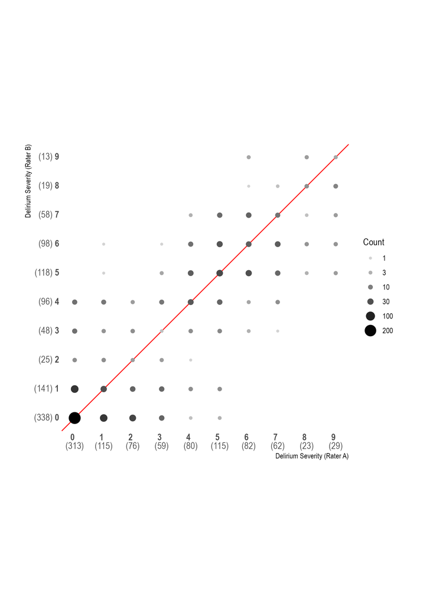

Consensus rating

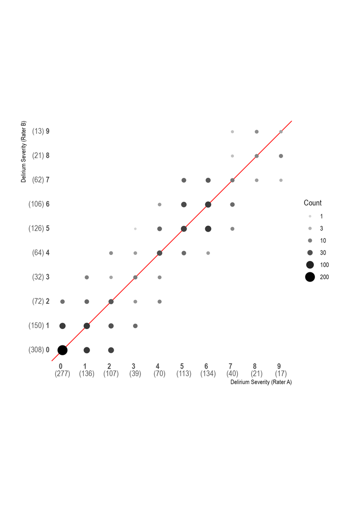

Combined figure

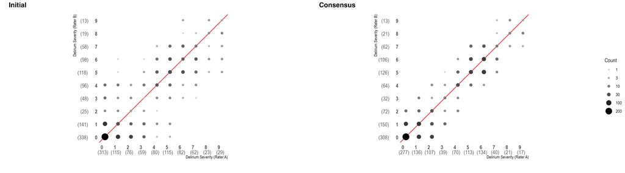

Weighted data

Initial rating

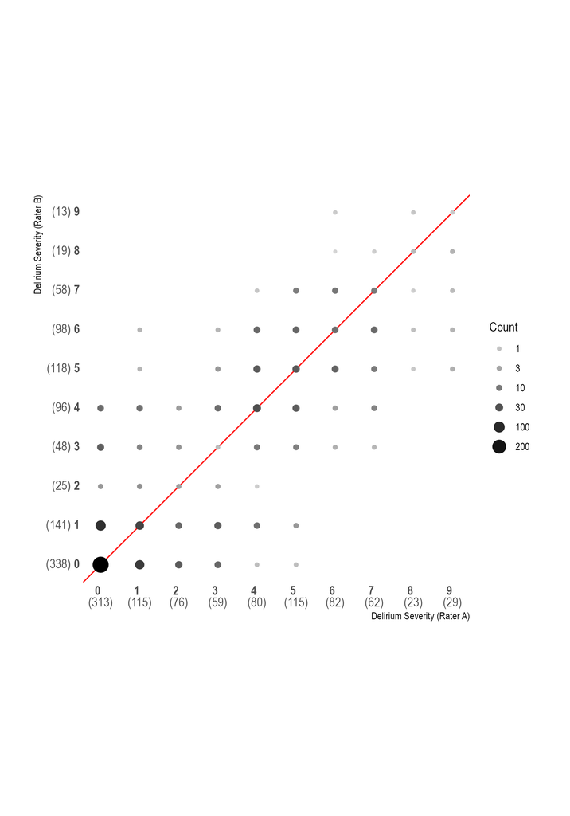

Consensus rating

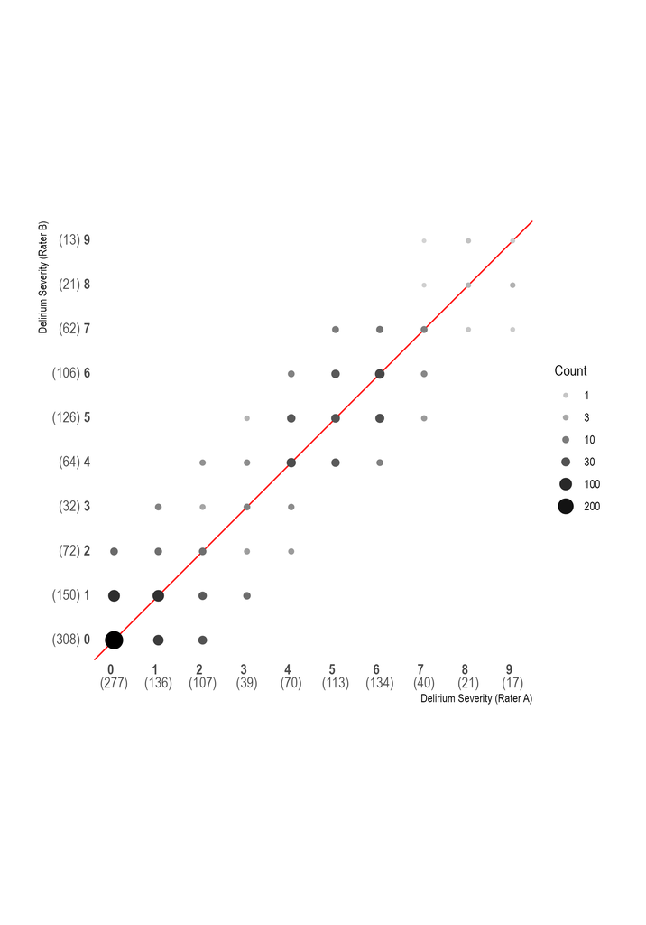

Combined figure

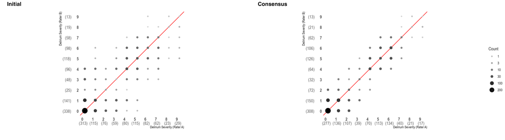

The unweighted correlation between rater A and rater B delirium severity ratings (0-9) prior to the consensus process was 0.84. After the consensus process, the correlation was 0.93. The kappa statistic went from 0.84 (0.82, 0.86) to 0.93 (0.92, 0.94).

The weighted correlation between rater A and rater B delirium severity ratings (0-9) prior to the consensus process was 0.82. After the consensus process, the correlation was 0.93.

## Delirium presence

Table 3: Crosstab of paired initial ratings of delirium presence (weighted)

| Delirium Presence B | Delirium Presence A 0 | Delirium Presence A 1 |
| --- | --- | --- |
| 0 | 587.4 | 45.2 |
| 1 | 61.3 | 260.1 |

Table 4: Crosstab of paired consensus ratings of delirium presence (weighted)

| Delirium Presence B | Delirium Presence A 0 | Delirium Presence A 1 |
| --- | --- | --- |
| 0 | 581.6 | 36.8 |
| 1 | 52.3 | 283.3 |

The correlation between rater A and rater B delirium presence ratings (Yes/No) prior to the consensus process was 0.77. After the consensus process, the correlation was 0.81. The kappa statistic went from 0.77 (0.73, 0.81) to 0.81 (0.77, 0.85).

# Bland Altman plots

## Delirium severity

Weighted Bland Altman plot - Initial rating

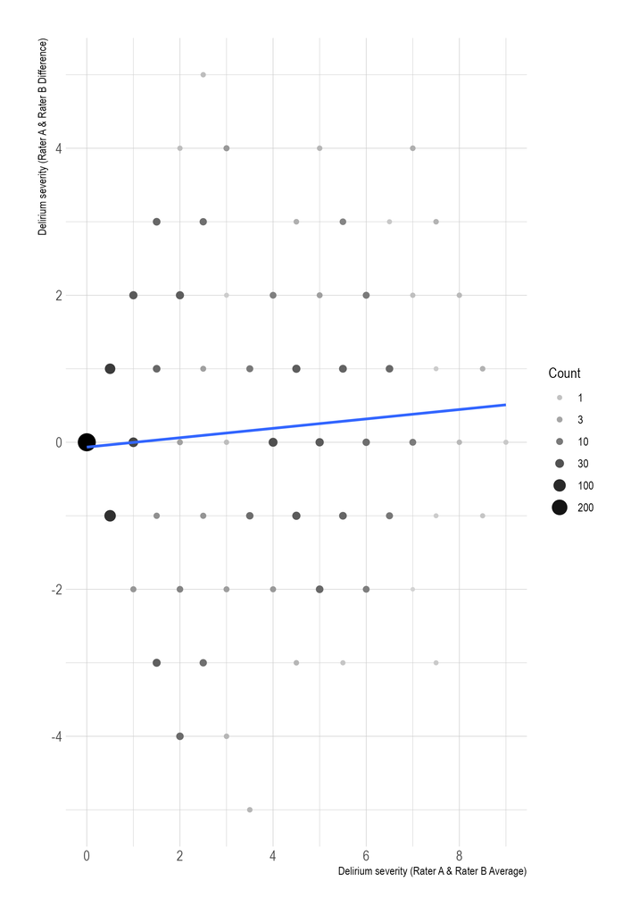

| **Characteristic** | **Beta** | **95% CI** | **p-value** |
| --- | --- | --- | --- |
| delirium_severity_avg | 0.03 | -0.13, 0.20 | 0.7 |

Abbreviation: CI = Confidence Interval

Weighted Bland Altman plot - consensus rating

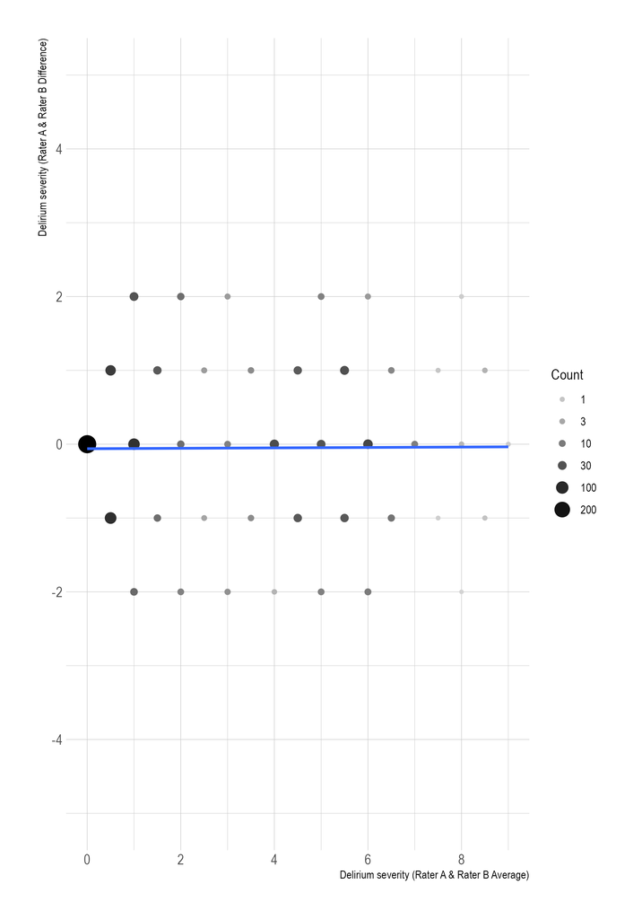

| **Characteristic** | **Beta** | **95% CI** | **p-value** |
| --- | --- | --- | --- |
| delirium_severity_avg | -0.01 | -0.13, 0.12 | >0.9 |

Abbreviation: CI = Confidence Interval